# Aula 2 - Distribuições de Probabilidade

PPEC

Estatística

Probabilidade

Estudo das distribuições Binomial, Normal e de Poisson, com aplicações em problemas de engenharia e ciência dos materiais.

Published

2026-07-10

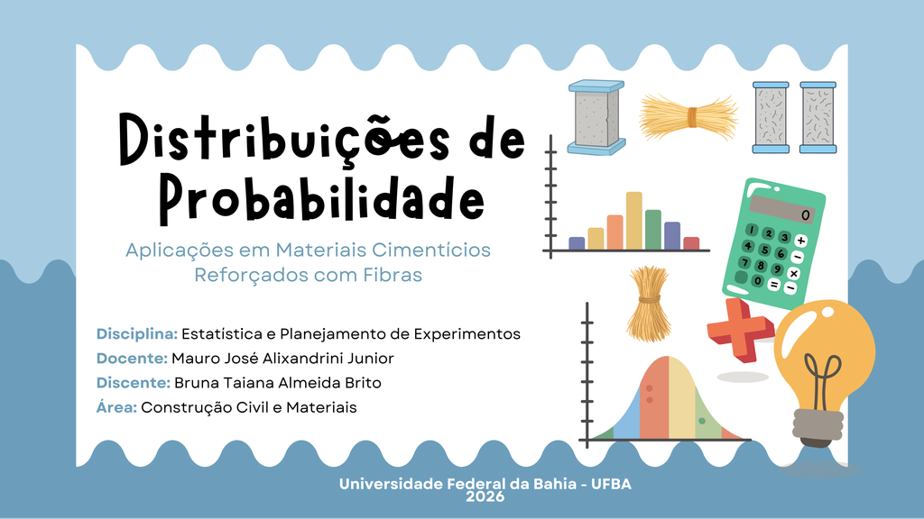

Distribuições de Probabilidade.png

# 1. Introdução

A análise de fenômenos na engenharia civil, especialmente na área de materiais, está intrinsecamente associada à variabilidade dos resultados experimentais. Propriedades como resistência mecânica, módulo de elasticidade, fissuração e durabilidade não são determinísticas, apresentando dispersões decorrentes de fatores como heterogeneidade dos materiais, variabilidade no processo de produção e incertezas inerentes aos ensaios experimentais.

Nesse contexto, a teoria das probabilidades e a estatística desempenham papel fundamental na modelagem e interpretação desses fenômenos, permitindo descrever o comportamento de variáveis aleatórias por meio de distribuições de probabilidade. Uma distribuição de probabilidade pode ser entendida como uma função que associa a cada valor possível de uma variável aleatória a sua respectiva probabilidade de ocorrência, representando, portanto, o comportamento estatístico de um fenômeno (Montgomery e Runger, 2014; Bittencourt, 2014).

De acordo com o material apresentado em aula, a distribuição de probabilidade expressa o comportamento de uma variável aleatória vinculada às probabilidades de ocorrência de seus possíveis resultados . Essa abordagem é essencial para compreender experimentos simples, como lançamentos de moedas, até aplicações mais complexas, como a análise de desempenho de materiais cimentícios.

Na engenharia de materiais, particularmente em compósitos cimentícios reforçados com fibras, a utilização de distribuições de probabilidade permite avaliar a variabilidade experimental e a confiabilidade dos resultados. Por exemplo, a resistência à flexão de elementos cimentícios pode ser modelada por distribuições contínuas, como a distribuição normal, enquanto a ocorrência de fissuras ou falhas pode ser analisada por distribuições discretas, como a binomial ou de Poisson.

A adoção de modelos probabilísticos é, portanto, indispensável para o planejamento de experimentos e para a interpretação adequada dos resultados, permitindo não apenas a determinação de valores médios, mas também a quantificação da dispersão e da incerteza associada às propriedades analisadas. Segundo Devore (2006), a utilização de métodos probabilísticos possibilita uma compreensão mais realista dos fenômenos de engenharia, uma vez que incorpora a variabilidade natural dos processos.

Além disso, a aplicação de ferramentas computacionais, como linguagens de programação e ambientes interativos (por exemplo, Python em notebooks), tem ampliado a capacidade de análise e visualização de dados, permitindo a implementação prática de modelos probabilísticos e facilitando a interpretação dos resultados experimentais.

Dessa forma, este trabalho tem como objetivo apresentar e discutir as principais distribuições de probabilidade (Binomial, Normal e de Poisson) com ênfase em suas aplicações na engenharia civil, especialmente no estudo de materiais cimentícios reforçados com fibras, integrando conceitos teóricos, exemplos aplicados e implementações computacionais.

# 2. Conceitos fundamentais

## 2.1 Variável aleatória

Uma variável aleatória é uma função que associa a cada resultado de um experimento aleatório um valor numérico. Essas variáveis podem ser classificadas em dois tipos principais: discretas e contínuas (Devore, 2006).

As variáveis aleatórias discretas assumem valores finitos ou enumeráveis, sendo comuns em experimentos que envolvem contagem, como o número de falhas em um conjunto de corpos de prova. Já as variáveis contínuas podem assumir qualquer valor em um intervalo, sendo típicas em medições físicas, como resistência, deformação e deslocamento.

No contexto da engenharia de materiais, a resistência à compressão ou à flexão de um compósito cimentício é um exemplo clássico de variável contínua, enquanto o número de fissuras em um elemento estrutural pode ser tratado como uma variável discreta.

## 2.2 Distribuição de probabilidade

A distribuição de probabilidade descreve como os valores de uma variável aleatória estão distribuídos, associando probabilidades a cada possível resultado. No caso de variáveis discretas, essa distribuição é definida por uma função de probabilidade. Para variáveis contínuas, é descrita por uma função densidade de probabilidade (Montgomery e Runger, 2014; Bittencourt, 2014).

As distribuições de probabilidade permitem não apenas descrever o comportamento dos dados, mas também realizar inferências e previsões, sendo fundamentais no planejamento e análise de experimentos.

## 2.3 Importância na engenharia civil

Na engenharia civil, a variabilidade dos materiais e dos processos construtivos torna indispensável o uso de modelos probabilísticos. A análise estatística permite (Pereira e Pereira, s.d.):

- Quantificar a dispersão dos resultados experimentais;
- Avaliar a confiabilidade de materiais e estruturas;
- Comparar diferentes composições ou processos;
- Apoiar a tomada de decisão em projetos e controle tecnológico.

Em materiais cimentícios reforçados com fibras, por exemplo, a variabilidade na distribuição das fibras, na aderência fibra-matriz e nas condições de moldagem influencia diretamente o comportamento mecânico, sendo essencial a utilização de distribuições de probabilidade para uma análise adequada desses sistemas.

# 3. Distribuição Binomial

A distribuição binomial é uma das principais distribuições de probabilidade discreta, sendo utilizada para modelar experimentos compostos por um número fixo de ensaios independentes, nos quais cada ensaio apresenta apenas dois resultados possíveis: sucesso ou fracasso.

Segundo Devore (2006), a distribuição binomial descreve o número de sucessos em uma sequência de experimentos independentes com probabilidade constante de ocorrência. Essa estrutura é amplamente utilizada em problemas de engenharia que envolvem decisões binárias, como aprovação ou falha de elementos estruturais.

o material apresentado em aula, esse conceito foi ilustrado por meio do lançamento de moedas, onde cada lançamento representa um ensaio e os resultados possíveis são “cara” (sucesso) ou “coroa” (fracasso) . Esse exemplo pode ser diretamente extrapolado para diversas aplicações na engenharia.

**Definição:**

Uma variável aleatória ( X ) segue uma distribuição binomial quando representa o número de sucessos em ( n ) ensaios independentes, cada um com probabilidade constante de sucesso ( p ).

### Função de probabilidade

$$P(X = k) = \binom{n}{k} p^k (1 - p)^{n - k}$$

Onde:

- ( n ): número total de ensaios
- ( k ): número de sucessos desejados
- ( p ): probabilidade de sucesso
- ( (1 - p) ): probabilidade de fracasso

A distribuição binomial permite avaliar a probabilidade de ocorrência de um determinado número de eventos em um conjunto finito de experimentos. Na engenharia civil, isso é particularmente útil na análise de fenômenos discretos, como a ocorrência de falhas em corpos de prova, presença de fissuras ou conformidade de elementos estruturais com critérios normativos.

**Exemplo 1 (Engenharia de materiais):**

Considere um conjunto de 10 corpos de prova de compósito cimentício reforçado com fibras vegetais. Suponha que a probabilidade de um corpo de prova apresentar fissuração precoce seja de 20% ( p = 0,2 ).

Deseja-se determinar a probabilidade de exatamente 3 corpos de prova apresentarem fissuração precoce.

Parâmetros do problema:

- ( n = 10 )
- ( k = 3 )
- ( p = 0,2 )

Esse tipo de abordagem permite avaliar a confiabilidade do material e compreender a variabilidade do comportamento experimental.

**Observação:**

A aplicação da distribuição binomial pressupõe que os ensaios sejam independentes e que a probabilidade de sucesso permaneça constante. Em materiais cimentícios, essas condições podem ser influenciadas por fatores como variabilidade na matriz, distribuição de fibras e condições de moldagem.

### Implementação computacional

Para complementar a análise teórica, é possível utilizar ferramentas computacionais para calcular probabilidades e visualizar o comportamento da distribuição binomial.

Neste exemplo, será considerada a situação previamente descrita, envolvendo corpos de prova de compósitos cimentícios reforçados com fibras. O objetivo é calcular a probabilidade de ocorrência de diferentes números de falhas (fissuração precoce) e representar graficamente essa distribuição.

A utilização de linguagens de programação, como Python, permite automatizar cálculos e gerar visualizações que facilitam a interpretação dos resultados, sendo uma ferramenta amplamente empregada no planejamento e análise de experimentos.

```python
# Importação das bibliotecas
import numpy as np
import matplotlib.pyplot as plt
from scipy.stats import binom

# Parâmetros do problema
n = 10
p = 0.2

# Valores possíveis
k = np.arange(0, n+1)

# Probabilidades
probabilidades = binom.pmf(k, n, p)

# Mostrar valores
for i in range(len(k)):
    print(f"P(X = {k[i]}) = {probabilidades[i]:.4f}")

# Gráfico
plt.figure()
plt.bar(k, probabilidades)
plt.xlabel("Número de falhas")
plt.ylabel("Probabilidade")
plt.title("Distribuição Binomial")
plt.show()
```

```
P(X = 0) = 0.1074
P(X = 1) = 0.2684
P(X = 2) = 0.3020
P(X = 3) = 0.2013
P(X = 4) = 0.0881
P(X = 5) = 0.0264
P(X = 6) = 0.0055
P(X = 7) = 0.0008
P(X = 8) = 0.0001
P(X = 9) = 0.0000
P(X = 10) = 0.0000
```

[figure not shown]

### Interpretação dos resultados

O gráfico apresentado ilustra a distribuição de probabilidade do número de corpos de prova que podem apresentar fissuração precoce.

Observa-se que os valores mais prováveis concentram-se em baixos números de falhas, o que é esperado considerando a probabilidade de falha adotada ( p = 0,2 ). À medida que o número de falhas aumenta, a probabilidade associada diminui significativamente.

Esse comportamento é coerente com sistemas em que a ocorrência de falhas individuais possui baixa probabilidade, sendo a distribuição binomial uma ferramenta adequada para representar esse tipo de fenômeno.

Na engenharia de materiais, essa análise permite avaliar a confiabilidade de compósitos cimentícios e compreender a variabilidade dos resultados experimentais, auxiliando na tomada de decisões quanto ao desempenho e segurança dos materiais.

# 4. Distribuição Normal

A distribuição normal é uma das mais importantes distribuições de probabilidade contínua, sendo amplamente utilizada na modelagem de fenômenos naturais e experimentais. Sua relevância decorre do fato de que diversos processos físicos e propriedades de materiais apresentam comportamento aproximadamente normal, especialmente quando influenciados por múltiplos fatores independentes.

Segundo Devore (2016), a distribuição normal é frequentemente empregada para representar variáveis contínuas, como resistência mecânica, deformações e propriedades físicas de materiais, devido à sua capacidade de descrever adequadamente a variabilidade experimental.

No contexto apresentado em aula, observou-se que, à medida que o número de ensaios aumenta, distribuições discretas, como a binomial, tendem a se aproximar da distribuição normal, evidenciando sua importância teórica e prática.

**Definição:**

Uma variável aleatória contínua segue uma distribuição normal quando sua função densidade de probabilidade apresenta formato simétrico em torno da média, sendo caracterizada pelos parâmetros média $( \mu )$ e desvio padrão $( \sigma )$.

### Função densidade de probabilidade

$$f(x) = \frac{1}{\sigma \sqrt{2\pi}} e^{-\frac{(x - \mu)^2}{2\sigma^2}}$$

Na expressão da função densidade, a média $( \mu )$ define a posição central da distribuição, enquanto o desvio padrão $( \sigma )$ controla a dispersão dos valores em torno dessa média. Assim, quanto maior o desvio padrão, mais espalhados estarão os dados. Quanto menor, mais concentrados eles estarão próximos ao valor médio.

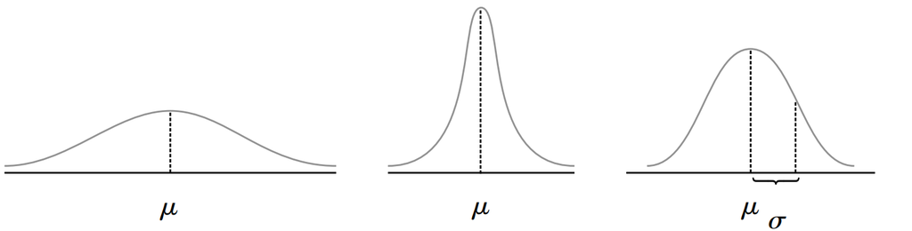

image.png

**Figura 1 –** Influência do desvio padrão na forma da distribuição normal. Fonte: Devore (2006).

### Propriedades da distribuição normal

A distribuição normal apresenta propriedades fundamentais que a tornam amplamente aplicável:

- É simétrica em torno da média;
- A média, a mediana e a moda coincidem;
- A área total sob a curva é igual a 1;
- A dispersão dos dados é controlada pelo desvio padrão;
- Valores mais distantes da média apresentam menor probabilidade de ocorrência.

Além disso, conforme discutido em aula, as probabilidades associadas à distribuição normal correspondem às áreas sob a curva, sendo possível determinar a probabilidade de ocorrência de determinados intervalos de valores.

### Normal reduzida (Padronização)

Para facilitar o cálculo de probabilidades, utiliza-se a transformação da variável original ( X ) em uma variável padronizada ( Z ). Essa transformação converte qualquer distribuição normal em uma distribuição normal padrão, cuja média é igual a 0 e o desvio padrão é igual a 1.

$$Z = \frac{X - \mu}{\sigma}$$

### Cálculo de probabilidades

Na distribuição normal, as probabilidades são obtidas a partir da área sob a curva. Para isso, utiliza-se a função distribuição acumulada, que representa a probabilidade da variável aleatória assumir valores menores ou iguais a um determinado valor.

Em termos gerais, essa probabilidade pode ser representada por:

$$P(X \leq x)$$

A partir dessa lógica, diferentes situações podem ser analisadas.

### Formas usuais de cálculo

As probabilidades mais frequentes na distribuição normal são:

- Probabilidade acumulada à esquerda:

$$P(X < a)$$

- Probabilidade à direita:

$$P(X > a) = 1 - P(X < a)$$

- Probabilidade entre dois valores:

$$P(a < X < b) = P(X < b) - P(X < a)$$

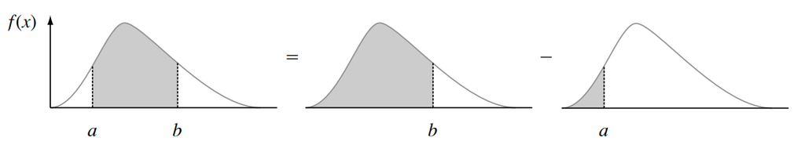

image.png

Essas relações são particularmente úteis na análise de resultados experimentais, permitindo quantificar a probabilidade de um material apresentar desempenho inferior, superior ou dentro de um intervalo de interesse.

### Regra empírica da distribuição normal

A distribuição normal apresenta uma propriedade importante conhecida como regra empírica, segundo a qual:

- Aproximadamente 68% dos valores encontram-se no intervalo $( \mu \pm 1\sigma )$;
- Aproximadamente 95% dos valores encontram-se no intervalo $( \mu \pm 2\sigma )$;
- Aproximadamente 99,7% dos valores encontram-se no intervalo $( \mu \pm 3\sigma )$.

Essa característica é extremamente útil na interpretação da variabilidade experimental, permitindo avaliar o quão dispersos estão os resultados obtidos em ensaios laboratoriais.

**Aplicação na engenharia de materiais:**

Na análise de materiais cimentícios reforçados com fibras, a distribuição normal pode ser empregada para representar propriedades contínuas, como resistência à compressão, resistência à flexão, absorção de água, módulo de elasticidade e outras respostas experimentais. Nesses casos, a média representa o comportamento central do material, enquanto o desvio padrão expressa a dispersão dos resultados, permitindo avaliar sua uniformidade e confiabilidade.

**Exemplo (Engenharia de materiais):**

Considere os resultados de resistência à flexão de corpos de prova de compósito cimentício reforçado com fibras vegetais.

Suponha que os resultados apresentem:

- média $ = 12 $ MPa
- desvio padrão $ = 2 $ MPa

Deseja-se determinar a probabilidade de um corpo de prova apresentar resistência inferior a 10 MPa.

Esse tipo de análise permite avaliar a confiabilidade do material e identificar a probabilidade de ocorrência de resultados abaixo de um limite crítico.

### Resolução do exemplo 1

Aplicando a transformação para a variável padronizada:

$$Z = \frac{X - \mu}{\sigma}$$

Substituindo os valores do problema:

$$Z = \frac{10 - 12}{2} = -1$$

Portanto, o problema passa a ser determinar:

$$P(X < 10) = P(Z < -1)$$

Pela distribuição normal padrão, essa probabilidade é aproximadamente igual a 0,1587, ou seja, cerca de 15,87%.

### Implementação computacional

Além da resolução analítica por padronização, a distribuição normal pode ser analisada por meio de ferramentas computacionais. O uso de Python permite calcular probabilidades de forma rápida e representar graficamente o comportamento da distribuição, facilitando a interpretação dos resultados experimentais.

No exemplo a seguir, será calculada a probabilidade de um corpo de prova apresentar resistência à flexão inferior a 10 MPa, considerando média de 12 MPa e desvio padrão de 2 MPa.

```python
import numpy as np
import matplotlib.pyplot as plt
from scipy.stats import norm

# Parâmetros do problema
mu = 12      # média
sigma = 2    # desvio padrão

# Intervalo de valores para o gráfico
x = np.linspace(mu - 4*sigma, mu + 4*sigma, 400)

# Função densidade da distribuição normal
y = norm.pdf(x, mu, sigma)

# Probabilidade de resistência inferior a 10 MPa
prob = norm.cdf(10, mu, sigma)

print(f"Probabilidade de resistência < 10 MPa: {prob:.4f}")

# Gráfico
plt.figure()
plt.plot(x, y, label="Distribuição Normal")
plt.xlabel("Resistência à flexão (MPa)")
plt.ylabel("Densidade de probabilidade")
plt.title("Distribuição Normal - Resistência à Flexão")

# Área sombreada
x_fill = np.linspace(mu - 4*sigma, 10, 200)
y_fill = norm.pdf(x_fill, mu, sigma)
plt.fill_between(x_fill, y_fill, alpha=0.5, label="P(X < 10 MPa)")

plt.legend()
plt.show()
```

```
Probabilidade de resistência < 10 MPa: 0.1587
```

[figure not shown]

### Interpretação dos resultados

O resultado indica que a probabilidade de um corpo de prova apresentar resistência à flexão inferior a 10 MPa é de aproximadamente 15,87%. Graficamente, essa probabilidade corresponde à área sob a curva normal à esquerda desse valor.

Na prática, esse tipo de análise é extremamente útil no controle tecnológico de materiais, pois permite quantificar o risco de obtenção de resultados abaixo de um limite de desempenho considerado aceitável. Em materiais cimentícios reforçados com fibras, isso contribui para a avaliação da uniformidade do processo produtivo e da confiabilidade mecânica do compósito.

A seguir, apresenta-se um segundo exemplo, voltado ao controle tecnológico do concreto, evidenciando a ampla aplicabilidade da distribuição normal em diferentes contextos da engenharia civil.

**Exemplo 2 (Controle tecnológico de materiais):**

Considere a resistência à compressão de um concreto produzido em laboratório, cujos resultados seguem aproximadamente uma distribuição normal.

Suponha que:

- média $= 30 $ MPa
- desvio padrão $= 4 $ MPa

Deseja-se determinar a probabilidade de um corpo de prova apresentar resistência superior a 35 MPa.

Esse tipo de análise é comum no controle tecnológico do concreto, permitindo avaliar a proporção de amostras que atendem a critérios de desempenho estabelecidos em projeto.

### Resolução do exemplo 2

Aplicando a padronização:

$$Z = \frac{X - \mu}{\sigma}$$

Substituindo os valores:

$$Z = \frac{35 - 30}{4} = 1,25$$

Assim, o problema se torna:

$$P(X > 35) = P(Z > 1,25)$$

Utilizando a distribuição normal padrão:

$$P(Z > 1,25) \approx 0,1056$$

Portanto, a probabilidade de um corpo de prova apresentar resistência superior a 35 MPa é de aproximadamente 10,56%.

### Interpretação do resultados

O resultado indica que apenas cerca de 10,56% dos corpos de prova apresentam resistência superior a 35 MPa, evidenciando que esse valor está relativamente distante da média da distribuição.

Na prática, essa análise permite avaliar o desempenho do concreto em relação a limites estabelecidos, sendo particularmente útil para verificar a qualidade da produção e a adequação do material às exigências de projeto.

Além disso, esse tipo de abordagem pode ser utilizado para definir critérios de aceitação, estimar probabilidades de não conformidade e apoiar decisões no controle tecnológico de materiais.

Portanto, a distribuição normal constitui uma ferramenta essencial na análise estatística de resultados experimentais em engenharia, especialmente quando se trata de propriedades contínuas. Sua aplicação permite descrever a variabilidade dos dados, estimar probabilidades de ocorrência e apoiar interpretações mais robustas sobre o comportamento dos materiais estudados.

# 5. Distribuição de Poisson

A distribuição de Poisson é uma distribuição de probabilidade discreta utilizada para modelar o número de ocorrências de um evento em um intervalo fixo de tempo, área, volume ou extensão, desde que esses eventos ocorram de forma independente e com uma taxa média aproximadamente constante.

Essa distribuição é empregada para representar a quantidade de eventos em um determinado intervalo, sendo especialmente útil em problemas de contagem. Essa distribuição é particularmente relevante quando se deseja modelar fenômenos relativamente raros, como defeitos, falhas localizadas, poros ou fissuras em materiais.

No contexto da engenharia de materiais, sua aplicação é bastante conveniente para descrever situações em que o interesse está centrado no número de ocorrências de um determinado evento por unidade de área, por corpo de prova ou por elemento analisado.

**Definição:**

Uma variável aleatória ( X ) segue uma distribuição de Poisson quando representa o número de vezes que um evento ocorre em um intervalo fixo, sendo esse comportamento descrito por uma taxa média de ocorrência $( \lambda )$.

### Função de probabilidade

$$P(X = k) = \frac{e^{-\lambda}\lambda^k}{k!}$$

Onde:

- ( k ) = número de ocorrências do evento;
- $( \lambda )$ = número médio de ocorrências no intervalo considerado;
- ( e ) = base do logaritmo natural.

Na distribuição de Poisson, a média e a variância são ambas iguais a $( \lambda )$, propriedade clássica dessa distribuição e muito útil na interpretação de dados de contagem.

### Condições de aplicação

A distribuição de Poisson é adequada quando:

- Os eventos são contados em um intervalo fixo;
- As ocorrências são independentes;
- A taxa média de ocorrência permanece aproximadamente constante;
- A probabilidade de ocorrência simultânea de muitos eventos em um intervalo muito pequeno é baixa.

Além disso, a distribuição de Poisson pode ser entendida como um caso limite da distribuição binomial quando o número de ensaios é grande, a probabilidade de sucesso em cada ensaio é pequena e o produto ( np ) permanece constante.

**Aplicação na engenharia de materiais:**

Na engenharia de materiais, a distribuição de Poisson pode ser utilizada para modelar o número de fissuras observadas em uma superfície, a quantidade de defeitos em um lote de amostras, o número de poros visíveis em uma seção analisada ou a ocorrência de falhas localizadas em compósitos cimentícios reforçados com fibras.

Esse tipo de abordagem é especialmente útil quando o interesse não está no valor contínuo de uma propriedade mecânica, mas sim na contagem de eventos discretos associados ao comportamento do material.

**Exemplo 1 (Fissuras em material cimentício):**

Suponha que, em uma determinada análise experimental, seja observado que uma placa de compósito cimentício reforçado com fibras apresenta, em média, 2 fissuras por área inspecionada.

Deseja-se determinar a probabilidade de serem observadas exatamente 3 fissuras nessa mesma área.

### Resolução do exemplo 1

Aplicando a função de probabilidade da distribuição de Poisson:

$$P(X = k) = \frac{e^{-\lambda}\lambda^k}{k!}$$

Substituindo os valores:

$$P(X = 3) = \frac{e^{-2}2^3}{3!}$$

$$P(X = 3) = \frac{e^{-2}\cdot 8}{6}$$

$$P(X = 3) \approx 0,1804$$

Portanto, a probabilidade de observar exatamente 3 fissuras na área analisada é de aproximadamente 18,04%.

**Exemplo 2 (Defeitos em corpos de prova):**

Considere que, em um processo de moldagem de corpos de prova de argamassa reforçada com fibras vegetais, o número médio de defeitos superficiais observados por amostra seja igual a 1,5.

Deseja-se determinar a probabilidade de uma amostra apresentar no máximo 1 defeito superficial.

### Resolução do exemplo 2

A probabilidade de uma amostra apresentar no máximo 1 defeito é dada por:

$$P(X \leq 1) = P(X = 0) + P(X = 1)$$

Calculando cada parcela:

$$P(X = 0) = \frac{e^{-1,5}(1,5)^0}{0!} = e^{-1,5}$$

$$P(X = 1) = \frac{e^{-1,5}(1,5)^1}{1!} = 1,5e^{-1,5}$$

Logo:

$$P(X \leq 1) = e^{-1,5} + 1,5e^{-1,5}$$

$$P(X \leq 1) \approx 0,5578$$

Assim, a probabilidade de uma amostra apresentar no máximo 1 defeito superficial é de aproximadamente 55,78%.

### Implementação computacional

A implementação computacional permite calcular rapidamente as probabilidades associadas à distribuição de Poisson e representar graficamente o comportamento da variável aleatória.

No exemplo a seguir, considera-se o caso em que o número médio de fissuras por área inspecionada é igual a 2. O objetivo é calcular as probabilidades para diferentes números de fissuras e visualizar a distribuição por meio de um gráfico de barras.

```python
import numpy as np
import matplotlib.pyplot as plt
from scipy.stats import poisson

# Parâmetro da distribuição
lam = 2  # número médio de fissuras

# Valores possíveis de ocorrência
k = np.arange(0, 11)

# Probabilidades
probabilidades = poisson.pmf(k, lam)

# Exibir probabilidades
for i in range(len(k)):
    print(f"P(X = {k[i]}) = {probabilidades[i]:.4f}")

# Probabilidade de exatamente 3 fissuras
prob_3 = poisson.pmf(3, lam)
print(f"\nProbabilidade de exatamente 3 fissuras: {prob_3:.4f}")

# Gráfico
plt.figure()
plt.bar(k, probabilidades)
plt.xlabel("Número de fissuras")
plt.ylabel("Probabilidade")
plt.title("Distribuição de Poisson - Número de fissuras")
plt.show()
```

```
P(X = 0) = 0.1353
P(X = 1) = 0.2707
P(X = 2) = 0.2707
P(X = 3) = 0.1804
P(X = 4) = 0.0902
P(X = 5) = 0.0361
P(X = 6) = 0.0120
P(X = 7) = 0.0034
P(X = 8) = 0.0009
P(X = 9) = 0.0002
P(X = 10) = 0.0000

Probabilidade de exatamente 3 fissuras: 0.1804
```

[figure not shown]

```python
import numpy as np
import matplotlib.pyplot as plt
from scipy.stats import poisson

lam = 2
k = np.arange(0, 11)
probabilidades = poisson.pmf(k, lam)

plt.figure()
bars = plt.bar(k, probabilidades)

# Destacar a barra referente a k = 3
bars[3].set_alpha(0.8)

plt.xlabel("Número de fissuras")
plt.ylabel("Probabilidade")
plt.title("Distribuição de Poisson - Destaque para P(X = 3)")
plt.show()
```

[figure not shown]

### Interpretação dos resultados

O gráfico evidencia o comportamento típico da distribuição de Poisson para contagens discretas. Observa-se que, para uma taxa média de 2 fissuras por área, os maiores valores de probabilidade concentram-se em pequenas contagens, enquanto números maiores de fissuras tornam-se progressivamente menos prováveis.

Na prática, esse tipo de análise é útil para avaliar a frequência esperada de defeitos ou fissuras em materiais cimentícios, contribuindo para o controle de qualidade e para a interpretação do comportamento experimental de compósitos reforçados com fibras.

# 6. Comparação entre distribuições

As distribuições binomial, normal e de Poisson apresentam características distintas, sendo aplicáveis a diferentes tipos de problemas na engenharia. De forma geral:

- A distribuição binomial é utilizada para modelar eventos discretos com dois resultados possíveis (sucesso ou fracasso);
- A distribuição normal é aplicada a variáveis contínuas, especialmente em fenômenos naturais e propriedades de materiais;
- A distribuição de Poisson é empregada na modelagem de eventos raros, associados à contagem de ocorrências em intervalos definidos.

Além disso, existe uma relação importante entre essas distribuições: a distribuição de Poisson pode ser interpretada como uma aproximação da distribuição binomial em situações em que o número de ensaios é elevado e a probabilidade de ocorrência é pequena, enquanto a distribuição normal pode aproximar a binomial quando o número de ensaios é suficientemente grande.

# 7. Considerações finais

A utilização de distribuições de probabilidade constitui uma ferramenta fundamental na análise de dados experimentais em engenharia civil, especialmente na área de materiais.

Por meio das distribuições binomial, normal e de Poisson, é possível modelar diferentes tipos de fenômenos, desde a ocorrência de falhas e eventos discretos até a variabilidade de propriedades contínuas, como resistência mecânica.

A integração entre teoria estatística e aplicação prática permite não apenas descrever o comportamento dos dados, mas também interpretar resultados experimentais de forma mais robusta, contribuindo para a avaliação da confiabilidade e do desempenho dos materiais.

Nesse contexto, o uso de ferramentas computacionais, como Python, potencializa a análise estatística, facilitando a visualização e o entendimento dos fenômenos estudados.

Portanto, a abordagem probabilística representa um elemento essencial no planejamento e análise de experimentos, sendo indispensável para o desenvolvimento de soluções mais seguras, eficientes e sustentáveis na engenharia.

# Referências

BITTENCOURT, H. R. Estatística Aplicada à Engenharia. PUCRS, 2014.

DEVORE, J. L. Probabilidade e estatística: para engenharia e ciências. (tradução Joaquim Pinheiro Nunes da Silva). São Paulo: Cengage Learning, 2006.

MONTGOMERY, D. C.; RUNGER, G. C. *Applied Statistics and Probability for Engineers*. 6. ed. Hoboken: Wiley, 2014.

PEREIRA, M. A. T.; PEREIRA, P. J. Notas de Aula de Estatística Aplicada à Engenharia. Material didático. s.d.